# MAST8820 – First Assessment

Solutions

Mirza Ameen Hyder

## Question 1:

Consider the data set `weightlifters.csv` available on Moodle, that contains information about 98 weightlifters divided into two training groups. After 2 months of training, it was measured how much improvement in weight they achieved regarding a specific movement, i.e., how many more kilograms they were able to lift in a specific movement.

1. Produce one plot that could show the difference between the distribution of weight improvement given the two training groups and comment.

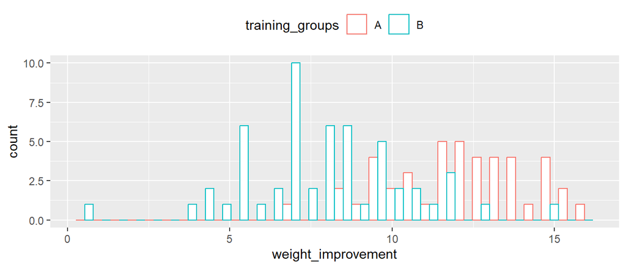

```r
library(dplyr)
library(tidyverse)
library(ggplot2)
library(readr)
library(MASS)

setwd('C:\\Users\\ameen\\Desktop\\assignment1_adv_reg_analysis')
df1 <- read_csv('weightlifters.csv', col_names = TRUE, show_col_types = FALSE)

hist_diff <-ggplot(df1, aes(x=weight_improvement, color=training_groups)) +
  geom_histogram(fill="white", position="dodge", alpha = 1)+
  theme(legend.position="top")
hist_diff
```

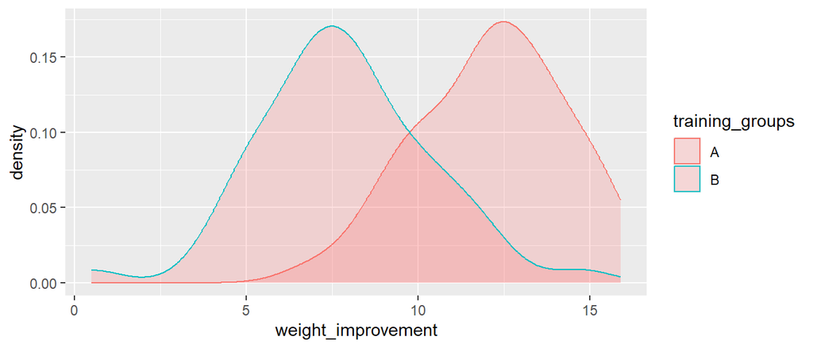

```r
density_diff <-ggplot(df1, aes(x=weight_improvement, color=training_groups)) +
  geom_density(fill="#FF6666", position="dodge", alpha = 0.2)
density_diff
```

2. Fit a simple linear regression model with weight improvament as the response variable and training group as the explanatory variable and output the summary of the model.

```r
lin_model <- lm(weight_improvement ~ training_groups, data = df1)
summary(lin_model)
```

```
##
## Call:
## lm(formula = weight_improvement ~ training_groups, data = df1)
##
## Residuals:
##     Min      1Q  Median      3Q     Max
## -7.3389 -1.4068  0.0646  1.6129  6.9611
##
## Coefficients:
##                  Estimate Std. Error t value Pr(>|t|)
## (Intercept)       12.1318     0.3531  34.356  < 2e-16 ***
## training_groupsB  -4.2929     0.4757  -9.024 1.86e-14 ***
## ---
## Signif. codes:  0 '***' 0.001 '**' 0.01 '*' 0.05 '.' 0.1 ' ' 1
##
## Residual standard error: 2.342 on 96 degrees of freedom
## Multiple R-squared:  0.459,  Adjusted R-squared:  0.4533
## F-statistic: 81.44 on 1 and 96 DF,  p-value: 1.855e-14
```

3. Interpret the simple linear regression model fitted in part b) by referring to the estimated intercept and slope of the model.

The intercept of the model shows that the estimated mean value of weight improvement is 12.13 kgs for training group A. The slope of the model show that on average training group B has 4.29 kgs less improvement in weight lifting than training group A. In other words, training group B has estimated mean value of 7.84 kgs in weight lifting capacity

4. Construct a 95% confidence intervals for the coefficients of the model fitted in part c).

```r
confint(lin_model)
```

```
##                      2.5 %    97.5 %
## (Intercept)      11.430882 12.832754
## training_groupsB -5.237196 -3.348663
```

```r
## formula used = estimate +(-) 1.96 * Std. Error
```

5. What does the summary of the model suggest about the importance of the different training routines as a predictor for weight improvement?

Given the estimates for the parameters, related p-values and even the confidence intervals presented in the previous item, we have evidence to say that different training groups/routines is important to explain the variation of weight improvement and hence can be used as a predictor. Hence, we reject the hypothesis that the effect of `training_groups` is equal to zero.

6. Plot the studentised residuals versus the fitted values of the model and comment.

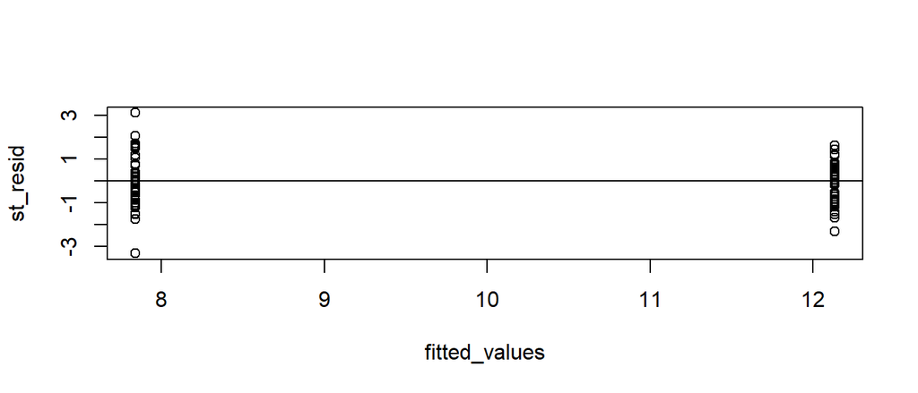

```r
st_resid <- studres(lin_model)
fitted_values <- predict.lm(lin_model,data.frame(training_groups = df1$training_groups))

df_resid_fit <- data.frame(`st_resid` = st_resid, `fitted_values` =  fitted_values)
df_resid_fit$pred_group = ifelse(fitted_values <= 12,'B','A')

plot(fitted_values ,st_resid)
abline(0,0)
```

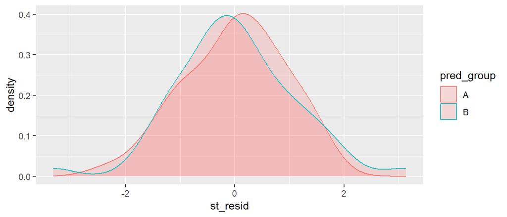

```r
ggplot(df_resid_fit, aes(x=st_resid, color=pred_group)) +
  geom_density(fill="#FF6666", position="dodge", alpha = 0.2)
```

For this model, it seems that the linearity assumption and the homocedasticity assumption are met. The majority of residuals for both groups are scattered around point 0 and ranging around maximum -2 and 2. Same observation can be made with the density plot as density of residuals for both training groups is concentrated around 0 with tails getting flatter around -2 and 2.

7. Produce a QQ-plot of the studentised residuals of the model fitted and comment.

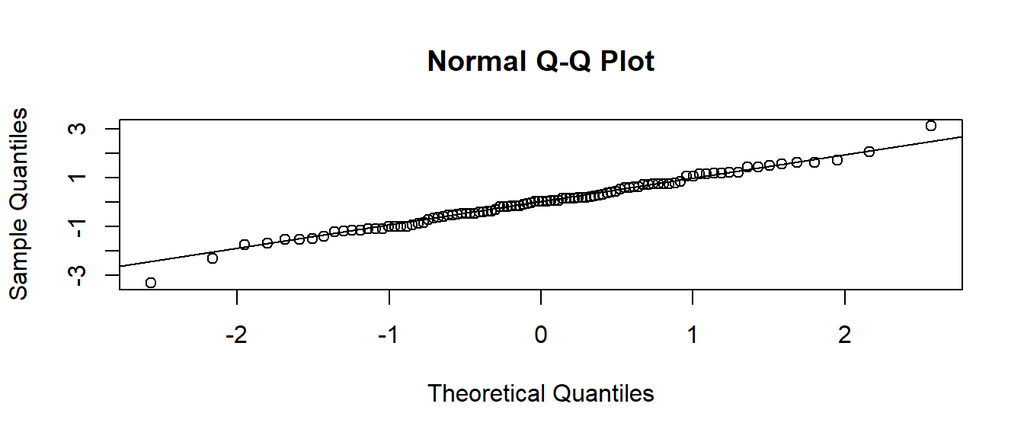

```r
qqnorm(st_resid)
qqline(st_resid)
```

The above qq-plot shows that the assumption of normality for the errors is met, as majority of the residuals roughly lies on the straight line.

8. Define the multiple R-squared that is reported in the summary of the model and comment on its value in this case.

The multiple R-squared for the model is equal to 0.459, which shows that this model is able to explain 45.9% of the variability in the weight improvements.

1. Plot the estimated normal densities given the parameters of the model and compare with the real values. Does this estimates show that model explain the variation of weight improvement as a function of the training groups?

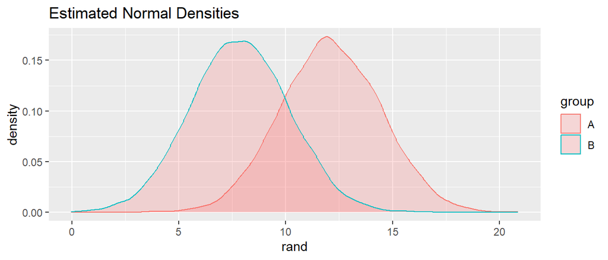

```r
densA <- data.frame('rand' = rnorm(10000, 12.1318, 2.342), 'group' = rep('A',10000))
densB <- data.frame('rand' = rnorm(10000, 7.8389, 2.342), 'group' = rep('B',10000))

est_dens <- rbind(densA,densB)


density_diff_est <-ggplot(est_dens, aes(x=rand, color = group)) +
  geom_density(fill="#FF6666", position="dodge", alpha = 0.2) + ggtitle('Estimated Normal Densities')

density_diff_est
```

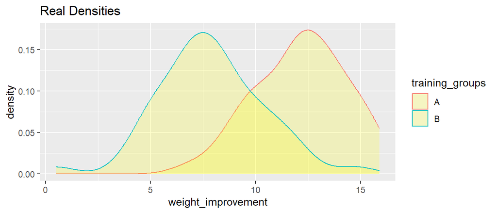

```r
density_diff_real <-ggplot(df1, aes(x=weight_improvement, color=training_groups)) +
  geom_density(fill="yellow", position="dodge", alpha = 0.2) + ggtitle('Real Densities')

density_diff_real
```

## Question 2:

Consider the data set `rent.csv` available on Moodle, with information about 297 people and how much they pay for rent. This data set should be considered only for modelling purposes and not as an actual sample of the population. It contains variables age, professional area (Education, Finance and Construction) and city (London and Canterbury), as well as their respective rent for a given month.

1. Produce a scatterplot of the data with age in the x-axis and rent in the y-axis and comment.

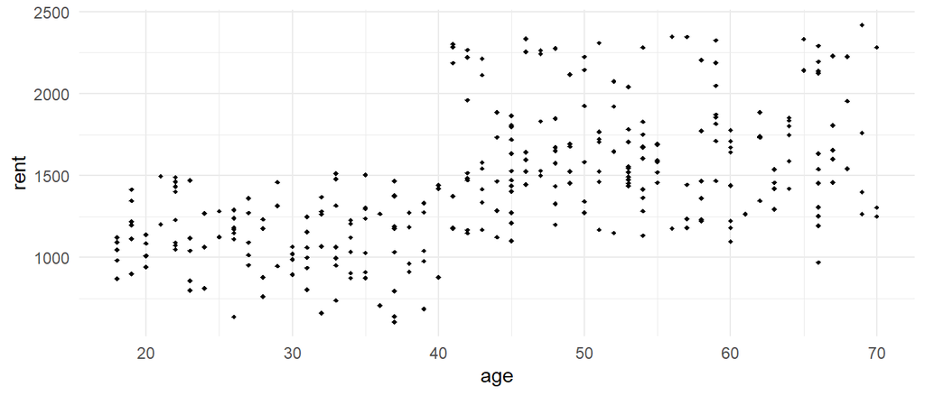

```r
df2 <- read_csv('rent.csv',  col_names = TRUE, show_col_types = FALSE)
ggplot(data=df2, aes(x=age,y=rent)) + geom_point(shape = 18, color = 'black', size = 1) + theme_minimal()
```

There is some rough linearly increasing relation between age and rent which outlines that people with higher ages tend to pay as their rents.

2. Fit a simple linear regression model with rent as the response variable and age, professional area and city as the explanatory variables. Output the summary of the model and interpret the model fitted.

```r
lin_model2 <- lm(data=df2, rent ~ age + cities + professional_area)
summary(lin_model2)
```

```
##
## Call:
## lm(formula = rent ~ age + cities + professional_area, data = df2)
##
## Residuals:
##     Min      1Q  Median      3Q     Max
## -618.55 -198.99   12.01  194.94  602.40
##
## Coefficients:
##                            Estimate Std. Error t value Pr(>|t|)
## (Intercept)                 451.859     53.515   8.444 1.46e-15 ***
## age                          16.133      1.012  15.944  < 2e-16 ***
## citiesLondon                 72.920     29.558   2.467   0.0142 *
## professional_areaEducation  193.759     36.358   5.329 1.98e-07 ***
## professional_areaFinance    515.370     35.960  14.332  < 2e-16 ***
## ---
## Signif. codes:  0 '***' 0.001 '**' 0.01 '*' 0.05 '.' 0.1 ' ' 1
##
## Residual standard error: 253.3 on 292 degrees of freedom
## Multiple R-squared:  0.6123, Adjusted R-squared:  0.6069
## F-statistic: 115.3 on 4 and 292 DF,  p-value: < 2.2e-16
```

The average rent paid by the people of age 0 that live in Canterbury, and have professional area as construction is around 451.859. However, the intercept term in this model does not make a lot of sense. Similarly, people living in London pay £72.920 more than the people living in Canterbury given that other variables remain constant. Also, with every 1 year of increment in age, the rent of a person tends to increase by £16.133 on average given that other variables remains constant. Lastly, the people belonging to Education and Finance tends to pay £193.759 and £515.370 more respectively in their rent as compared to people belonging to Construction given that other variables remain constant.

3. Update the model fitted in part b) adding an interaction term between professional area and city. Interpret the results obtained and outline the differences with the conclusion in part b).

```r
lin_model3 <- lm(data=df2, rent ~ age + (cities * professional_area))
summary(lin_model3)
```

```
##
## Call:
## lm(formula = rent ~ age + (cities * professional_area), data = df2)
##
## Residuals:
##     Min      1Q  Median      3Q     Max
## -536.66 -132.90    9.93  161.74  495.30
##
## Coefficients:
##                                         Estimate Std. Error t value Pr(>|t|)
## (Intercept)                             541.2412    50.4838  10.721  < 2e-16
## age                                      15.6004     0.9045  17.248  < 2e-16
## citiesLondon                            -77.9316    45.7840  -1.702   0.0898
## professional_areaEducation              222.1850    44.6826   4.973 1.13e-06
## professional_areaFinance                269.2461    45.2799   5.946 7.87e-09
## citiesLondon:professional_areaEducation -33.3672    65.0211  -0.513   0.6082
## citiesLondon:professional_areaFinance   472.6951    64.2592   7.356 1.95e-12
##
## (Intercept)                             ***
## age                                     ***
## citiesLondon                            .
## professional_areaEducation              ***
## professional_areaFinance                ***
## citiesLondon:professional_areaEducation
## citiesLondon:professional_areaFinance   ***
## ---
## Signif. codes:  0 '***' 0.001 '**' 0.01 '*' 0.05 '.' 0.1 ' ' 1
##
## Residual standard error: 225.8 on 290 degrees of freedom
## Multiple R-squared:  0.6941, Adjusted R-squared:  0.6878
## F-statistic: 109.7 on 6 and 290 DF,  p-value: < 2.2e-16
```

Model 2 has interaction terms in it and that is the reason why estimates for different groups has been changed.

4. Plot the studentised residuals of versus the fitted values of the model fitted in part c) and comment.

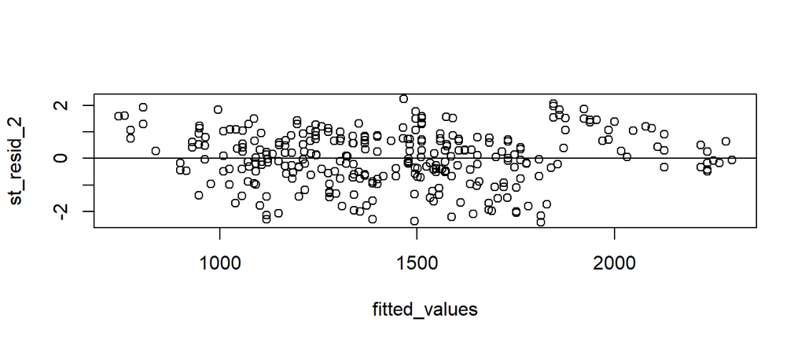

```r
st_resid_2 <- studres(lin_model3)
fitted_values <- predict.lm(lin_model3,df2[, c('age', 'cities', 'professional_area')])

plot(fitted_values ,st_resid_2)
abline(0,0)
```

For this model, it seems that the linearity assumption and the homocedasticity assumption are met. The majority of residuals for the fitted values are scattered around point 0 and ranging around maximum -2 and 2.

5. Produce a QQ-plot of the studentised residuals of the model model fitted in part c) and comment.

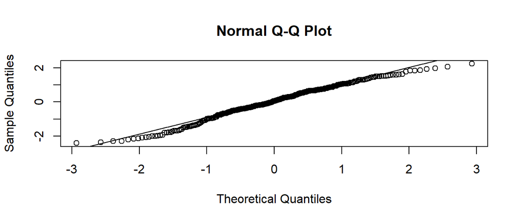

```r
qqnorm(st_resid_2)
qqline(st_resid_2)
```

The above qq-plot shows that the assumption of normality for the errors is met, as majority of the residuals roughly lies on the straight line in the range of -1 and 1. There are some minor deviations from the straight line at the extremes but as their quanitity is quite low it would be safe to ignore them.

6. Consider the method ”forward selection” to pick one model to explain the variation of rent as a function of age, professional area and city with any important interaction term and comment the results. Find out which interaction is important

```r
FitFirst <- lm(data=df2, rent ~ 1)

Fitall1 <- lm(data=df2, rent ~ age + (cities * professional_area) + (cities * age) + (age * professional_area) + (age * professional_area * cities))

step(FitFirst, scope = formula(Fitall1) , direction = 'forward')
```

```
## Start:  AIC=3565.97
## rent ~ 1
##
##                     Df Sum of Sq      RSS    AIC
## + age                1  15117315 33215178 3456.6
## + professional_area  2  12865215 35467278 3478.0
## + cities             1    994789 47337704 3561.8
## <none>                           48332493 3566.0
##
## Step:  AIC=3456.56
## rent ~ age
##
##                     Df Sum of Sq      RSS    AIC
## + professional_area  2  14084115 19131063 3296.7
## + cities             1    991696 32223482 3449.6
## <none>                           33215178 3456.6
##
## Step:  AIC=3296.71
## rent ~ age + professional_area
##
##                         Df Sum of Sq      RSS    AIC
## + age:professional_area  2   1638744 17492319 3274.1
## + cities                 1    390602 18740461 3292.6
## <none>                               19131063 3296.7
##
## Step:  AIC=3274.11
## rent ~ age + professional_area + age:professional_area
##
##          Df Sum of Sq      RSS    AIC
## + cities  1    294838 17197481 3271.1
## <none>                17492319 3274.1
##
## Step:  AIC=3271.06
## rent ~ age + professional_area + cities + age:professional_area
##
##                            Df Sum of Sq      RSS    AIC
## + cities:professional_area  2   3769571 13427910 3201.6
## + age:cities                1   2030429 15167052 3235.7
## <none>                                  17197481 3271.1
##
## Step:  AIC=3201.58
## rent ~ age + professional_area + cities + age:professional_area +
##     professional_area:cities
##
##              Df Sum of Sq      RSS    AIC
## + age:cities  1   1732463 11695447 3162.6
## <none>                    13427910 3201.6
##
## Step:  AIC=3162.55
## rent ~ age + professional_area + cities + age:professional_area +
##     professional_area:cities + age:cities
##
##                                Df Sum of Sq      RSS    AIC
## + age:cities:professional_area  2   1445381 10250066 3127.4
## <none>                                      11695447 3162.6
##
## Step:  AIC=3127.37
## rent ~ age + professional_area + cities + age:professional_area +
##     professional_area:cities + age:cities + age:professional_area:cities
```

```
##
## Call:
## lm(formula = rent ~ age + professional_area + cities + age:professional_area +
##     professional_area:cities + age:cities + age:professional_area:cities,
##     data = df2)
##
## Coefficients:
##                                 (Intercept)
##                                    259.8365
##                                         age
##                                     21.8887
##                  professional_areaEducation
##                                    228.3683
##                    professional_areaFinance
##                                    344.4541
##                                citiesLondon
##                                    744.4948
##              age:professional_areaEducation
##                                     -0.3053
##                age:professional_areaFinance
##                                     -1.3633
##     professional_areaEducation:citiesLondon
##                                    -74.9416
##       professional_areaFinance:citiesLondon
##                                   -456.5325
##                            age:citiesLondon
##                                    -18.3422
## age:professional_areaEducation:citiesLondon
##                                      0.6999
##   age:professional_areaFinance:citiesLondon
##                                     20.4328
```

Comment: According to forward selection, the full model has the lowest AIC, i.e., all the variables and their possible interaction terms are important in predicting the rent of specific group of people. In other words, the rent for people with a specific age, city and profession tends to vary in a different way then the people with other age, city and profession. One more important observation is that age and professional area tends to play bigger role in predicting the rents of individuals as compared to where they live in as cities variable is added in the forward selection after age and profession has been added. This observation is also consistent with the models made in previous parts where cities were having low significane and higher p-values.

7. Plot the estimated densities of rent given the model selected in the previous item.

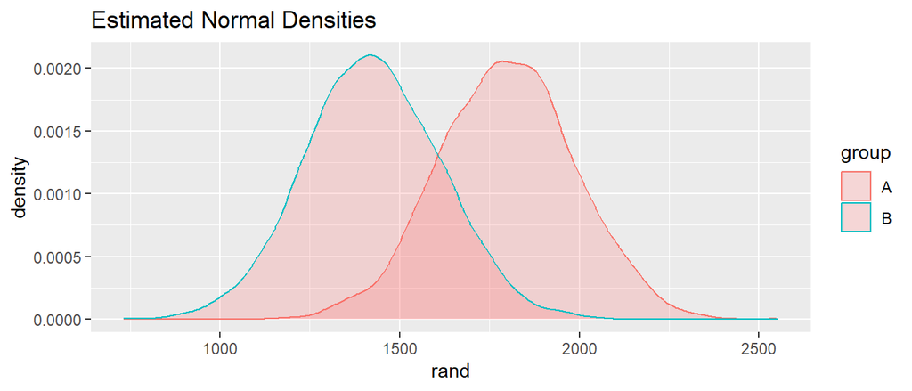

```r
lin_model4 <- lm(data=df2, rent ~  age + (cities * professional_area) + (cities * age) + (age * professional_area) + (age * professional_area * cities))

## selected group A: city: London, professional_area: Finance and age = 40 (mean age of the data)

is_london =  1
is_finance = 1
is_education = 0
age = 40

mean1 <- round(coef(lin_model4)[1], 2)  + (age * round(coef(lin_model4)[2], 2)) + (is_london * round(coef(lin_model4)[3], 2))  + (is_education * round(coef(lin_model4)[4], 2)) + (is_finance * round(coef(lin_model4)[5], 2)) + (is_london * is_education * round(coef(lin_model4)[6], 2))  + (is_london * is_finance *(round(coef(lin_model4)[7], 2)))  + (age * is_london * round(coef(lin_model4)[8], 2)) + (age * is_education * round(coef(lin_model4)[9], 2))  + (age * is_finance * round(coef(lin_model4)[10], 2)) + (age * is_london * is_education * round(coef(lin_model4)[11], 2))  + (age * is_london * is_finance * round(coef(lin_model4)[12], 2))

## selected group B: city: Canterb, professional_area: Finance and age = 40 (mean age of the data)

is_london =  0
is_finance = 1
is_education = 0
age = 40


mean2 <- round(coef(lin_model4)[1], 2)  + (age * round(coef(lin_model4)[2], 2)) + (is_london * round(coef(lin_model4)[3], 2))  + (is_education * round(coef(lin_model4)[4], 2)) + (is_finance * round(coef(lin_model4)[5], 2)) + (is_london * is_education * round(coef(lin_model4)[6], 2))  + (is_london * is_finance *(round(coef(lin_model4)[7], 2)))  + (age * is_london * round(coef(lin_model4)[8], 2)) + (age * is_education * round(coef(lin_model4)[9], 2))  + (age * is_finance * round(coef(lin_model4)[10], 2)) + (age * is_london * is_education * round(coef(lin_model4)[11], 2))  + (age * is_london * is_finance * round(coef(lin_model4)[12], 2))

st_dev <- 189.6

groupA <- data.frame('rand' = rnorm(10000, mean1, st_dev), 'group' = rep('A',10000))
groupB <- data.frame('rand' = rnorm(10000, mean2, st_dev), 'group' = rep('B',10000))


est_dens <- rbind(groupA,groupB)


density_diff_est <-ggplot(est_dens, aes(x=rand, color = group)) +
  geom_density(fill="#FF6666", position="dodge", alpha = 0.2) + ggtitle('Estimated Normal Densities')

density_diff_est
```